# PrepTemperature_GFDL

Phoebe.Woodworth-Jefcoats@noaa.gov

8/13/2020

## Purpose

The purpose of this script is to create time series of temperature for the therMizer FishMIP runs. There are four climate scenarios:

- picontrol: pre-industrial climate as simulated by the Earth System Models (ESMs)
- historical: historical climate as simulated by the ESMs, starting in 1950
- ssp126: SSP1-RCP2.6 climate as simulated by the ESMs
- ssp585" SSP5-RCP8.5 climate as simulated by the ESMs

and both ssp126 and ssp585 will be appended to historical. Note that only the years 1950 - 2100 are needed.

## Ocean Temperature

To facilitate comparison with the previous FishMIP simulations, we’ll use the same approach: annual data, with surface and bottom temperatures averaged for all species except mahi, wahoo, blue marlin, and striped marlin (for which we’ll use only surface temperatures). Time-permitting, it would be worthwhile to use species-specific depth-averaged temperatures is in [Woodworth-Jefcoats et al. 2019](https://www.frontiersin.org/articles/10.3389/fmars.2019.00383/full) and compare the results. Likewise for monthly data.

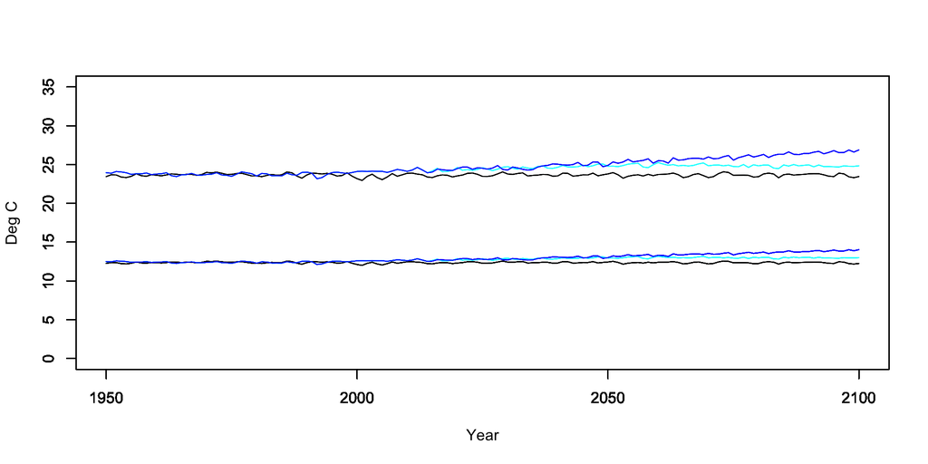

```r
### Load GFDL-ESM4 data
picon <- read.csv('Hawaii_GFDL-ESM4_picontrol_annual_1601_2100.csv', header = TRUE)
hist <- read.csv('Hawaii_GFDL-ESM4_historical_annual_1850_2014.csv', header = TRUE)
ssp126 <- read.csv('Hawaii_GFDL-ESM4_ssp126_annual_2015_2100.csv', header = TRUE)
ssp585 <- read.csv('Hawaii_GFDL-ESM4_ssp585_annual_2015_2100.csv', header = TRUE)

# Create array and fill
picon_out <- array(numeric(), c(2100-1950+1,12)) # years 1950 - 2100 by 12 species
hist_out <- array(numeric(), c(2014-1950+1,12)) # years 1950 - 2014 by 12 species
ssp126_out <- array(numeric(), c(2100-2015+1,12)) # years 2015 - 2100 by 12 species
ssp585_out <- array(numeric(), c(2100-2015+1,12)) # years 2015 - 2100 by 12 species

# Identify the years of interest
picon_yrs <- which(picon$Date..yyyy. >= 1950)
hist_yrs <- which(hist$Date..yyyy. >= 1950)

# Loop through the 12 species in the Hawaii longline simulation
for (s in seq(1,12,1)) {
  # Based on how species are ordered in the model parameter table,
  # species 2 (Mahi), 7 (StripedMarin), 8 (Wahoo), and 10 (BlueMarlin)
  # will be affected by surface temperature only
  # whereas the others will experience the water column average
    if (s == 2 | s == 7 | s == 8 | s == 10) {
        picon_out[,s] <- picon$tos..degC.[picon_yrs]
        hist_out[,s] <- hist$tos..degC.[hist_yrs]
        ssp126_out[,s] <- ssp126$tos..degC.
        ssp585_out[,s] <- ssp585$tos..degC.
    } else {
        picon_out[,s] <- ((picon$tos..degC.[picon_yrs] + picon$tob..degC.[picon_yrs]) / 2)
        hist_out[,s] <- ((hist$tos..degC.[hist_yrs] + hist$tob..degC.[hist_yrs]) / 2)
        ssp126_out[,s] <- ((ssp126$tos..degC. + ssp126$tob..degC.) / 2)
        ssp585_out[,s] <- ((ssp585$tos..degC. + ssp585$tob..degC.) / 2)
    }
}
### Save output for input into mizerNPAC
picon_times <- seq(1950,2100,1)
hist_times <- seq(1950,2014,1)
ssp126_times <- seq(2015,2100,1)
ssp585_times <- seq(2015,2100,1)

species_names <- c("Bigeye","Mahi","BlueShark","Skipjack","Yellowfin","Albacore","StripedMarlin","Wahoo","Swordfish","BlueMarlin","Lancetfish","Opah") # to match case with therMizer parameters

picon_ocean_temp_array <- array(NA, dim = c(length(picon_times), length(species_names)), dimnames = list(time = picon_times, sp = species_names))

hist_ocean_temp_array <- array(NA, dim = c(length(hist_times), length(species_names)), dimnames = list(time = hist_times, sp = species_names))

ssp126_ocean_temp_array <- array(NA, dim = c(length(ssp126_times), length(species_names)), dimnames = list(time = ssp126_times, sp = species_names))

ssp585_ocean_temp_array <- array(NA, dim = c(length(ssp585_times), length(species_names)), dimnames = list(time = ssp585_times, sp = species_names))

picon_ocean_temp_array[,] <- picon_out[,]
hist_ocean_temp_array[,] <- hist_out[,]
ssp126_ocean_temp_array[,] <- ssp126_out[,]
ssp585_ocean_temp_array[,] <- ssp585_out[,]

# Concatonate historical and climate change scenarios
CCscenario_126 <- rbind(hist_ocean_temp_array,ssp126_ocean_temp_array)
CCscenario_585 <- rbind(hist_ocean_temp_array,ssp585_ocean_temp_array)

# Plot to check
for (s in seq(1,11,1)){
  plot(picon_times, picon_ocean_temp_array[,s], type= "l", col = "black", xlab = " ", ylab = " ", xlim = c(1950,2100), ylim = c(0,35))
  par(new = TRUE)
  plot(picon_times, CCscenario_126[,s], type= "l", col = "cyan", xlab = " ", ylab = " ", xlim = c(1950,2100), ylim = c(0,35))
  par(new = TRUE)
  plot(picon_times, CCscenario_585[,s], type= "l", col = "blue", xlab = " ", ylab = " ", xlim = c(1950,2100), ylim = c(0,35))
  par(new = TRUE)
}
plot(picon_times, picon_ocean_temp_array[,12], type = "l", col = "black", xlab = "Year", ylab = "Deg C", xlim = c(1950,2100), ylim = c(0,35))
par(new = TRUE)
plot(picon_times, CCscenario_126[,12], type = "l", col = "cyan", xlab = " ", ylab = " ", xlim = c(1950,2100), ylim = c(0,35))
par(new = TRUE)
plot(picon_times, CCscenario_585[,12], type = "l", col = "blue", xlab = " ", ylab = " ", xlim = c(1950,2100), ylim = c(0,35))
```

```r
write.table(picon_ocean_temp_array, file = "GFDL_ocean_temp_array_PIcontrol.dat", quote = FALSE, row.names = TRUE, col.names = TRUE)
write.table(hist_ocean_temp_array, file = "GFDL_ocean_temp_array_hist.dat", quote = FALSE, row.names = TRUE, col.names = TRUE)
write.table(ssp126_ocean_temp_array, file = "GFDL_ocean_temp_array_ssp126.dat", quote = FALSE, row.names = TRUE, col.names = TRUE)
write.table(ssp585_ocean_temp_array, file = "GFDL_ocean_temp_array_ssp585.dat", quote = FALSE, row.names = TRUE, col.names = TRUE)
write.table(CCscenario_126, file = "GFDL_ocean_temp_array_CCscenario_126.dat", quote = FALSE, row.names = TRUE, col.names = TRUE)
write.table(CCscenario_585, file = "GFDL_ocean_temp_array_CCscenario_585.dat", quote = FALSE, row.names = TRUE, col.names = TRUE)
```